# Assignment 5

Nithin varma

2022-12-01

```r
 Cerealsdata <- read.csv("C:/Users/Kittu Varma/Downloads/Cereals.csv")
```

```r
library(fastDummies)
library(caret)
library(car)
library(tidyverse)
library(cluster)
library(stats)
library(factoextra)
library(cluster)
library(hrbrthemes)
library(GGally)
library(viridis)
library(fpc)
library(caTools)
```

#DataPreprocessing

#Removing all cereals with missing values

```r
Cerealsdata<-na.omit(Cerealsdata)
```

#Confirming that each record is unique

```r
record<- as.data.frame(table(Cerealsdata[1]))
```

#Adding row names

```r
row.names(Cerealsdata)<- Cerealsdata[,1]
```

#removing the name coloums

```r
Cerealsdata<-Cerealsdata[,-1]
```

#reviewing data structure

```r
str(Cerealsdata)
```

```
## 'data.frame':    74 obs. of  15 variables:
##  $ mfr     : chr  "N" "Q" "K" "K" ...
##  $ type    : chr  "C" "C" "C" "C" ...
##  $ calories: int  70 120 70 50 110 110 130 90 90 120 ...
##  $ protein : int  4 3 4 4 2 2 3 2 3 1 ...
##  $ fat     : int  1 5 1 0 2 0 2 1 0 2 ...
##  $ sodium  : int  130 15 260 140 180 125 210 200 210 220 ...
##  $ fiber   : num  10 2 9 14 1.5 1 2 4 5 0 ...
##  $ carbo   : num  5 8 7 8 10.5 11 18 15 13 12 ...
##  $ sugars  : int  6 8 5 0 10 14 8 6 5 12 ...
##  $ potass  : int  280 135 320 330 70 30 100 125 190 35 ...
##  $ vitamins: int  25 0 25 25 25 25 25 25 25 25 ...
##  $ shelf   : int  3 3 3 3 1 2 3 1 3 2 ...
##  $ weight  : num  1 1 1 1 1 1 1.33 1 1 1 ...
##  $ cups    : num  0.33 1 0.33 0.5 0.75 1 0.75 0.67 0.67 0.75 ...
##  $ rating  : num  68.4 34 59.4 93.7 29.5 ...
```

```r
distance <- dist(Cerealsdata, method = "euclidean")
```

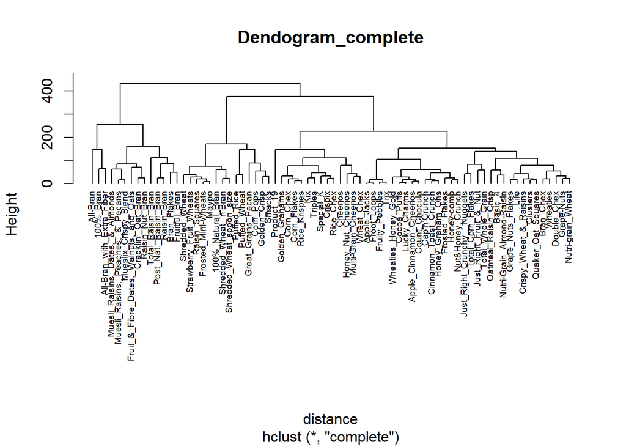

```r
# Hierarchical clustering using Complete Linkage
hc1 <- hclust(distance, method = "complete")
# Plot the obtained dendrogram
plot(hc1, cex = 0.6, hang = -1, main = "Dendogram_complete")
```

#Use Agnes to compare the clustering from single linkage, complete linkage, average linkage, and Ward. Choose the best method.

```r
# vector of methods to compare
m <- c( "average", "single", "complete", "ward")
names(m) <- c( "average", "single", "complete", "ward")
# function to compute coefficient
ac <- function(x) {
agnes(Cerealsdata, method = x)$ac
}
map_dbl(m, ac)
```

```
##   average    single  complete      ward
## 0.8786692 0.7297141 0.9225732 0.9595040
```

#ward linkage has the strongest clustering structure

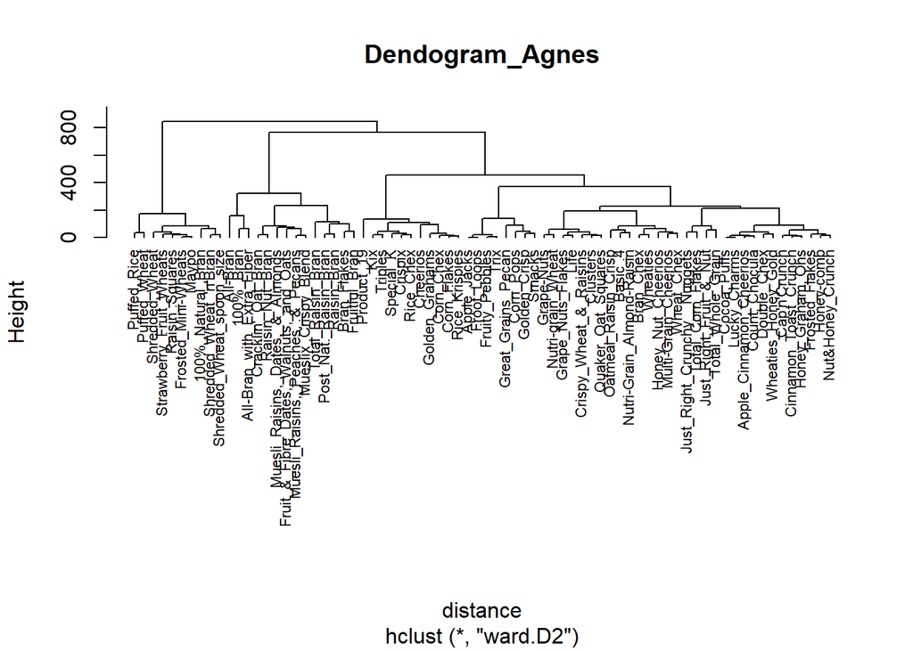

```r
hc3<-hclust(distance,method = "ward.D2")
plot(hc3, cex = 0.7, hang = -1, main = "Dendogram_Agnes")
```

#differnece between Hieracial clustering and K means is that: K-Means is that it needs us to pre-enter the number of clusters (K) but Hierarchical clustering has no such requirements to do so.